# Family Guy

Loading the usual suspects!

```r
library(dplyr)
library(stringr)
library(rvest)
library(ggplot2)
```

# A brief description

The below paragraph for the *Family Guy* series which created by *Seth MacFarlane*, has been scraped directly from the [Wikipedia](https://en.wikipedia.org/wiki/Family_Guy) page. I hide the source code here for more readability. Please refer to [ASSIGNMENT 2.Rmd](https://github.com/SaeedPourjafar/RRcourse2022/blob/7d8f55fc5417e7a8878b6161db2cfd3b840a249a/RR_Mar_30_31/ASSIGNMENT%202.Rmd) for the source code. Enjoy!

> Family Guy is an American adult animated sitcom created by Seth MacFarlane and developed by MacFarlane and David Zuckerman for the Fox Broadcasting Company that premiered on January 31, 1999. The series is produced by Fuzzy Door Productions.

# A SHOT from the show

In case you are curious to meet the Griffin’s lovely family, here’s a nice SHOT from them.

[figure not shown]

# A summary of some basic statistics

For this point, after scraping some data in R which corresponds to [this table](https://en.wikipedia.org/wiki/Family_Guy#Episodes). We found that currently there are **20** seasons aired on FOX network from **January 31, 1999** up until now. The average number of episodes for each season is **19**. For more details we can see the details in the table below which shows the season, number of episodes, rank, first and last aired date amont the number of viewers in million:

| Season | Episodes | First aired | Last aired | Rank | Viewers(in millions) |
| --- | --- | --- | --- | --- | --- |
| 1 | 7 | 1999-01-31 | 1999-05-16 | 33 | 12.80 |
| 2 | 21 | 1999-09-23 | 2000-08-01 | 114 | 6.32 |
| 3 | 22 | 2001-07-11 | 2003-11-09 | 125 | 4.50 |
| 4 | 30 | 2005-05-01 | 2006-05-21 | 68 | 7.90 |
| 5 | 18 | 2006-09-10 | 2007-05-20 | 71 | 7.20 |
| 6 | 12 | 2007-09-23 | 2008-05-04 | 84 | 7.94 |
| 7 | 16 | 2008-09-28 | 2009-05-17 | 69 | 7.56 |
| 8 | 21 | 2009-09-27 | 2010-06-20 | 53 | 7.73 |
| 9 | 18 | 2010-09-26 | 2011-05-22 | 56 | 7.66 |
| 10 | 23 | 2011-09-25 | 2012-05-20 | 63 | 7.30 |
| 11 | 22 | 2012-09-30 | 2013-05-19 | 62 | 6.94 |
| 12 | 21 | 2013-09-29 | 2014-05-18 | 78 | 6.11 |
| 13 | 18 | 2014-09-28 | 2015-05-17 | 94 | 5.86 |
| 14 | 20 | 2015-09-27 | 2016-05-22 | 111 | 4.28 |
| 15 | 20 | 2016-09-25 | 2017-05-21 | 116 | 3.93 |
| 16 | 20 | 2017-10-01 | 2018-05-20 | 136 | 3.52 |
| 17 | 20 | 2018-09-30 | 2019-05-12 | 131 | 3.33 |
| 18 | 20 | 2019-09-29 | 2020-05-17 | 107 | 2.65 |
| 19 | 20 | 2020-09-27 | 2021-05-16 | 120 | 2.19 |
| 20 | 20 | 2021-09-26 | TBA | TBA | TBA |

# A graph of the viewership over time

Here’s the plot of number of viewers in million per season.

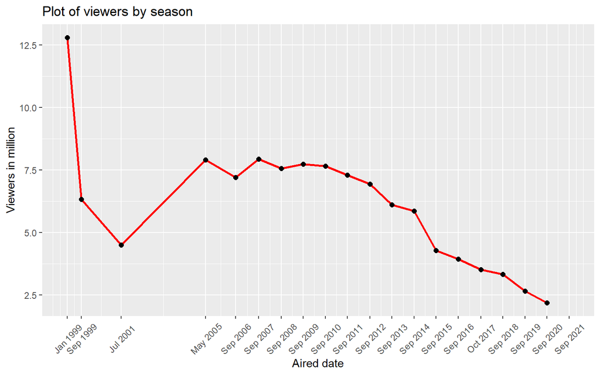

# A graph of the season-to-season changes in viewership

And here’s the plot of of the season-to-season changes in viewership.

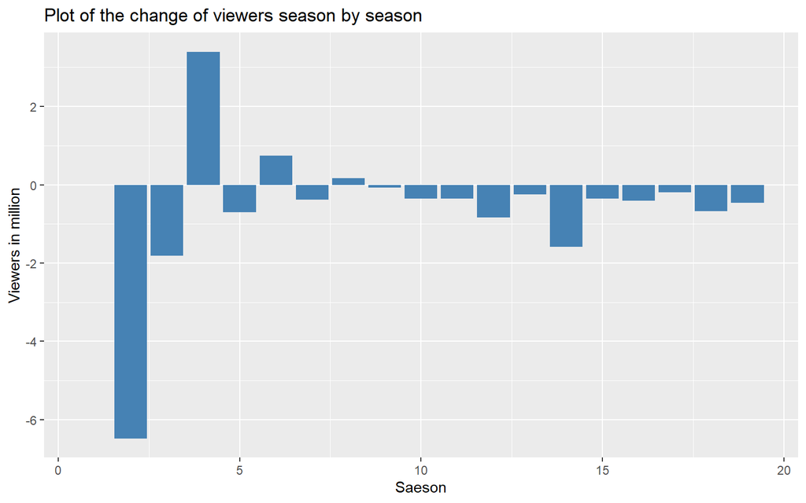

# A short description of the observed changes

No shows or series can lasts forever. As we can observe from the plot above, we can immediately recognize the decreased changes of number of viewers through seasons. This change can be seen as a dramatic shift between season 1 and 2 in which the number of viewers has been decreased by **50.62** percent. However the good news is that the after that the show gains some positive feedback which the result can bee seen in the changes from season 3 to season 4 where the number of viewers increased by **75.56**. In the end the average number of viewers as of now is **6.09** millions.

[^1]: University of Warsaw, m.pourjafar@student.uw.edu.pl